# Algorithmik & Statistik Lab 2: Finaler Bericht - ‘Rescue Snoopy’

Lara Knapwost - 1810837601, Cornelia Reithmeier - 1810837362, Isabelle Veitl - 1810837521, Anna Weber - 1810837818

Juni 2019

Unter dem Arbeitstitel “Rescue Snoopy” wurden die unten beschriebenen Daten ausgewählt, analysiert, das statistische Analyse-Interesse dargelegt und dann mit Hilfe von Decision Tree und Neuronalen Netzwerk-Modellen durchgeführt. Die gemeinsame Arbeit an diesem Projekt wurde über Github abgewickelt und dokumentiert: https://github.com/Co-Re/RescueSnoopy007

# Ausgewähltes Datenset

Für die Gruppenarbeit werden Daten von Kaggle verwendet:  
https://www.kaggle.com/aaronschlegel/austin-animal-center-shelter-intakes-and-outcomes#aac_intakes.csv

Von den dort gesammelten Daten wird folgende Datei verwendet: `aac_intakes_outcomes`

Das Datenset enthält unter anderem folgende Variablen:

- `animal_id` - eindeutige ID des Tieres
- `age_upon_outcome` - Alter des Tieres bei Outcome
- `date_of_birth` - Geburtsdatum des Tieres (geschätzt, wenn dieses nicht bekannt war)
- `outcome_subtype` - spezifische Beschreibung des Outcomes
- `outcome_type` - Art des Outcomes
- `datetime` - Datum und Uhrzeit des Outcomes
- `outcome_number` - Anzahl, wie oft ein Tier das Tierheim schon verlassen hat
- `sex_upon_outcome` - Geschlecht des Tieres und ob das Tier kastriert wurde
- `age_upon_intake` - Alter des Tieres bei Aufnahme in String-Format
- `animal_type` - Tierart
- `breed` - Tierrasse
- `color` - Tierfarbe
- `datetime` - Datum und Uhrzeit der Aufnahme
- `found_location` - Adresse oder Bereich, wo das Tier gefunden wurde
- `intake_condition` - Zustand des Tieres bei der Aufnahme
- `intake_type` - kategorisierter Aufnahmetyp
- `name` - Name des Tieres
- `sex_upon_intake` - Geschlecht des Tieres und ob das Tier kastriert wurde
- `intake_number` - Anzahl, wie oft ein Tier schon zum Tierheim gebracht wurde
- `time_in_shelter` - Zeit im Tierheim

Neben diesen Variablen existierten weitere, die beispielsweise Zeiträume in einem anderen Format darstellen.

## Hintergrundinformationen zum Datenset

Die Daten wurden vom [Austin Animal Center](http://www.austintexas.gov/department/aac) erhoben. Dieses Animal Center ist das größte Tierheim in den USA, in dem keine Tiere getötet werden und kann bis zu 18.000 Tiere pro Jahr aufnehmen. Es werden alle Arten von Tieren aufgenommen. Das Tierheim befindet sich im Travis County im US-Bundesstaat Texas. Die Daten werden im Rahmen der Austin Open Data Intitiative online bereitgestellt.

Das Datenset enthält n = 79.672 Observationen und 41 Variablen.  
Die Daten stammen aus der Zeit zwischen Oktober 2013 bis April 2018 (Outcomes).  
Die Tiere sind zwischen 0-25 Jahre alt, der Median liegt bei 1 Jahr, die Geschlechtsverteilung männlicher und weiblicher Tiere liegt fast bei 50/50.  
Mehr als die Hälfte der Tiere sind Hunde, gefolgt von Katzen und einigen Vögeln (<500). Etwa 4.500 Tiere sind keiner Spezies zugeordnet.  
Knapp die Hälfte der im Datenset enthaltenen Tiere wurde adoptiert.

## Statistische Lernaufgabe

Im Rahmen der Gruppenarbeit soll ein Klassifikationsproblem betrachtet werden:

Vorhersage des Outcome-Types auf Basis der gegebenen Variablen. Die initale Idee war es, die Prädiktoren zu finden, anhand derer eine Rückgabe an den Besitzer, ein Transfer / eine Adoption, Euthanasie, Tod etc. möglichst genau (durch Vorhersage der Klasse) vorhergesagt werden können. Im Zuge des Preprocessings und nach detaillierten Auseinandersetzungen stellte sich heraus, dass für viele der angeführten Outcome-Typen wenige Fälle vorhanden sind, sodass eine Modellierung ohne Overfitting schwierig erscheint. Deshalb wurde während des Projektes bzw. zu Ende des Preprocessings der Datensatz auf Tierarten mit mindestens n=500 eingeschränkt und ausschließlich der Outcome-Type *Adoption* verwendet.

## Motivation

Es gibt viele Tierheime und durch Hörensagen ist bekannt, dass in vielen davon eine Großzahl der Tiere einen beträchtlichen Teil ihres Lebens verbringen. Es ist interessant für uns, herauszufinden, welche Aspekte ausschlaggebend dafür sind, ob das Tier (vor dem Tod) wieder aus dem Tierheim “entlassen” wird, d.h. einen neuen Besitzer findet. Wir haben einige Hypothesen, welche wir prüfen möchten. Wir gehen davon aus, dass vor allem jüngere, gesunde Tiere eine bessere Chance haben, als ältere, kranke, ggf. auch nicht kastrierte (Streuner-)Tiere, die bereits sehr lange im Tierheim sind.  
Weiß man, welche Aspekte eine Rolle spielen, könnte man diese gezielt in den Tierheimen in der Kommunikation verwenden, um mehr Tieren (z.B. vor allem jenen, die grundsätzlich eine schlechtere Chance für eine Adoption haben) ein neues zu Hause zu geben. Außerdem könnten die Modelle das Tierheim in der Planung (z.B. der verfügbaren Plätze) unterstützen.  
Wir haben uns für dieses Datenset mit dieser Fragestellung entschieden, da einige von uns selbst Haustiere besitzen und wir den Eindruck haben, dass es bereits ausreichend viele Analysen zu ökonomischen Fragestellungen gibt.

# Initiales Preprocessing

## Laden der Daten

```r
aac_intakes_outcomes = read.csv("aac_intakes_outcomes.csv")
```

## Überprüfung der Datenstruktur

**Code Details**

```r
str(aac_intakes_outcomes)
```

```
## 'data.frame':    79672 obs. of  41 variables:
##  $ age_upon_outcome          : Factor w/ 46 levels "0 years","1 day",..: 8 42 40 8 15 14 14 14 14 17 ...
##  $ animal_id_outcome         : Factor w/ 71961 levels "A006100","A047759",..: 1 1 1 2 3 4 5 6 7 8 ...
##  $ date_of_birth             : Factor w/ 5923 levels "1991-12-11 00:00:00",..: 2090 2090 2090 1044 50 76 188 171 126 45 ...
##  $ outcome_subtype           : Factor w/ 20 levels "","Aggressive",..: 1 1 1 14 1 1 1 1 1 1 ...
##  $ outcome_type              : Factor w/ 10 levels "","Adoption",..: 8 8 8 10 8 8 8 8 8 8 ...
##  $ sex_upon_outcome          : Factor w/ 6 levels "Intact Female",..: 3 3 3 3 3 5 1 3 3 5 ...
##  $ age_upon_outcome_.days.   : int  3650 2555 2190 3650 5840 5475 5475 5475 5475 6570 ...
##  $ age_upon_outcome_.years.  : num  10 7 6 10 16 15 15 15 15 18 ...
##  $ age_upon_outcome_age_group: Factor w/ 10 levels "(-0.025, 2.5]",..: 10 9 9 10 4 3 3 3 3 5 ...
##  $ outcome_datetime          : Factor w/ 65686 levels "2013-10-01 10:39:00",..: 61651 18115 5545 6809 1458 1497 16619 14199 6180 29474 ...
##  $ outcome_month             : int  12 12 3 4 11 11 11 9 3 9 ...
##  $ outcome_year              : int  2017 2014 2014 2014 2013 2013 2014 2014 2014 2015 ...
##  $ outcome_monthyear         : Factor w/ 55 levels "2013-10","2013-11",..: 51 15 6 7 2 2 14 12 6 24 ...
##  $ outcome_weekday           : Factor w/ 7 levels "Friday","Monday",..: 5 3 3 2 3 4 1 2 4 1 ...
```

[output cut: 27 more lines]

```r
# Andrucken der ersten Datensätze
head(aac_intakes_outcomes)
```

```
##   age_upon_outcome animal_id_outcome       date_of_birth outcome_subtype
## 1         10 years           A006100 2007-07-09 00:00:00
## 2          7 years           A006100 2007-07-09 00:00:00
## 3          6 years           A006100 2007-07-09 00:00:00
## 4         10 years           A047759 2004-04-02 00:00:00         Partner
## 5         16 years           A134067 1997-10-16 00:00:00
## 6         15 years           A141142 1998-06-01 00:00:00
##      outcome_type sex_upon_outcome age_upon_outcome_.days.
## 1 Return to Owner    Neutered Male                    3650
## 2 Return to Owner    Neutered Male                    2555
## 3 Return to Owner    Neutered Male                    2190
## 4        Transfer    Neutered Male                    3650
## 5 Return to Owner    Neutered Male                    5840
## 6 Return to Owner    Spayed Female                    5475
##   age_upon_outcome_.years. age_upon_outcome_age_group    outcome_datetime
```

[output cut: 69 more lines]

**Code Details**

```r
summary(aac_intakes_outcomes)
```

```
##  age_upon_outcome animal_id_outcome             date_of_birth
##  1 year  :14750   A721033:   13     2014-05-05 00:00:00:  112
##  2 years :11542   A706536:   11     2015-09-01 00:00:00:  112
##  2 months: 9246   A718223:   11     2014-04-21 00:00:00:  106
##  3 years : 5277   A616444:    8     2015-04-28 00:00:00:  104
##  3 months: 3401   A694501:    8     2016-05-01 00:00:00:  103
##  1 month : 3396   A716018:    8     2015-04-20 00:00:00:  100
##  (Other) :32060   (Other):79613     (Other)            :79035
##     outcome_subtype           outcome_type        sex_upon_outcome
##             :43324   Adoption       :33594   Intact Female: 9308
##  Partner    :19840   Transfer       :23799   Intact Male  : 9732
##  Foster     : 5490   Return to Owner:14791   Neutered Male:28293
##  SCRP       : 3205   Euthanasia     : 6244   NULL         :    1
##  Suffering  : 2549   Died           :  690   Spayed Female:25549
##  Rabies Risk: 2539   Disposal       :  304   Unknown      : 6789
##  (Other)    : 2725   (Other)        :  250
##  age_upon_outcome_.days. age_upon_outcome_.years.
##  Min.   :   0            Min.   : 0.0000
##  1st Qu.:  90            1st Qu.: 0.2466
##  Median : 365            Median : 1.0000
##  Mean   : 782            Mean   : 2.1426
##  3rd Qu.:1095            3rd Qu.: 3.0000
##  Max.   :9125            Max.   :25.0000
##
##  age_upon_outcome_age_group            outcome_datetime outcome_month
##  (-0.025, 2.5]:59412        2016-04-18 00:00:00:   39   Min.   : 1.000
##  (2.5, 5.0]   :11068        2015-08-11 00:00:00:   25   1st Qu.: 4.000
##  (7.5, 10.0]  : 3619        2017-10-17 00:00:00:   25   Median : 7.000
##  (5.0, 7.5]   : 3423        2015-07-02 00:00:00:   22   Mean   : 6.655
##  (10.0, 12.5] : 1057        2015-11-17 00:00:00:   21   3rd Qu.:10.000
##  (12.5, 15.0] :  868        2014-10-20 09:00:00:   16   Max.   :12.000
##  (Other)      :  225        (Other)            :79524
##   outcome_year  outcome_monthyear  outcome_weekday   outcome_hour
##  Min.   :2013   2014-07: 2072     Friday   :10735   Min.   : 0.0
##  1st Qu.:2014   2015-06: 1975     Monday   :11429   1st Qu.:12.0
##  Median :2015   2015-07: 1900     Saturday :12848   Median :15.0
##  Mean   :2015   2015-05: 1876     Sunday   :12310   Mean   :14.3
##  3rd Qu.:2017   2014-08: 1851     Thursday :10216   3rd Qu.:17.0
##  Max.   :2018   2017-07: 1774     Tuesday  :11688   Max.   :23.0
##                 (Other):68224     Wednesday:10446
```

[output cut: 57 more lines]

```
##  2015-06: 2188    Friday   :11205   Min.   : 0.00   Min.   : 1.000
##  2015-05: 2092    Monday   :11997   1st Qu.:11.00   1st Qu.: 1.000
##  2016-05: 2035    Saturday :12037   Median :13.00   Median : 1.000
##  2014-05: 1956    Sunday   :10335   Mean   :13.49   Mean   : 1.127
##  2014-07: 1885    Thursday :10995   3rd Qu.:16.00   3rd Qu.: 1.000
##  2017-05: 1883    Tuesday  :11528   Max.   :23.00   Max.   :13.000
##  (Other):67633    Wednesday:11575
##                   time_in_shelter  time_in_shelter_days
##  0 days 00:06:00.000000000:   77   Min.   :   0.000
##  0 days 00:11:00.000000000:   77   1st Qu.:   1.102
##  0 days 00:12:00.000000000:   77   Median :   4.987
##  0 days 00:14:00.000000000:   77   Mean   :  16.757
##  0 days 00:17:00.000000000:   77   3rd Qu.:  13.611
##  0 days 00:13:00.000000000:   76   Max.   :1606.194
##  (Other)                  :79211
```

### Datenbereinigung I - Konvertieren der Datentypen

```r
aac_intakes_outcomes$animal_id_outcome <- as.character(aac_intakes_outcomes$animal_id_outcome)
aac_intakes_outcomes$date_of_birth <- anytime(aac_intakes_outcomes$date_of_birth)

aac_intakes_outcomes$sex_upon_outcome[is.na(aac_intakes_outcomes$sex_upon_outcome)] <- "Unknown"
aac_intakes_outcomes$sex_upon_outcome[is.element(aac_intakes_outcomes$sex_upon_outcome, "NULL")] <- "Unknown"
aac_intakes_outcomes$sex_upon_outcome_first <- as.factor(sapply(strsplit(as.character(aac_intakes_outcomes$sex_upon_outcome), " "), "[", 1))
aac_intakes_outcomes$sex_upon_outcome_second <- sapply(strsplit(as.character(aac_intakes_outcomes$sex_upon_outcome), " "), "[", 2)
aac_intakes_outcomes$sex_upon_outcome_second[is.na(aac_intakes_outcomes$sex_upon_outcome_second)] <- "Unknown"
aac_intakes_outcomes$sex_upon_outcome_second <- as.factor(aac_intakes_outcomes$sex_upon_outcome_second)

aac_intakes_outcomes$age_upon_outcome_.days. <- as.numeric(aac_intakes_outcomes$age_upon_outcome_.days.)
aac_intakes_outcomes$outcome_datetime <- anytime(aac_intakes_outcomes$outcome_datetime)
aac_intakes_outcomes$outcome_month <- as.factor(aac_intakes_outcomes$outcome_month)
aac_intakes_outcomes$outcome_year <- as.factor(aac_intakes_outcomes$outcome_year)
aac_intakes_outcomes$outcome_hour <- as.factor(hour(aac_intakes_outcomes$outcome_datetime))
aac_intakes_outcomes$dob_month <- as.factor(aac_intakes_outcomes$dob_month)
aac_intakes_outcomes$dob_year <- as.factor(aac_intakes_outcomes$dob_year)
aac_intakes_outcomes$animal_id_intake <- as.character(aac_intakes_outcomes$animal_id_intake)

aac_intakes_outcomes$sex_upon_intake[is.na(aac_intakes_outcomes$sex_upon_intake)] <- "Unknown"
aac_intakes_outcomes$sex_upon_intake_first <- as.factor(sapply(strsplit(as.character(aac_intakes_outcomes$sex_upon_intake), " "), "[", 1))
aac_intakes_outcomes$sex_upon_intake_second <- sapply(strsplit(as.character(aac_intakes_outcomes$sex_upon_intake), " "), "[", 2)
aac_intakes_outcomes$sex_upon_intake_second[is.na(aac_intakes_outcomes$sex_upon_intake_second)] <- "Unknown"
aac_intakes_outcomes$sex_upon_intake_first[is.na(aac_intakes_outcomes$sex_upon_intake_first)] <- "Unknown"
aac_intakes_outcomes$sex_upon_intake_second <- as.factor(aac_intakes_outcomes$sex_upon_intake_second)

aac_intakes_outcomes$count <- as.numeric(aac_intakes_outcomes$count)
aac_intakes_outcomes$age_upon_intake_.days. <- as.numeric(aac_intakes_outcomes$age_upon_intake_.days.)
aac_intakes_outcomes$intake_datetime <- anytime(aac_intakes_outcomes$intake_datetime)
aac_intakes_outcomes$intake_month <- as.factor(aac_intakes_outcomes$intake_month)
aac_intakes_outcomes$intake_year <- as.factor(aac_intakes_outcomes$intake_year)
aac_intakes_outcomes$intake_hour <- as.factor(hour(aac_intakes_outcomes$intake_datetime))
```

### Anmerkungen für weitere Preprocessing Schritte

Folgende Animal-Types sind vorhanden:

```
##
##  Bird   Cat   Dog Other
##   339 29539 45366  4428
```

Unter Other verbergen sich großteils unterschiedliche Nage- und Säugetiere bzw. Kleintiere, die in einem folgenden Datenaufbereitungsschritt feingliedriger aufgedrosselt werden.

Folgende Kombinationen sind bei der Zeugungsfähigkeit des Geschlechts möglich, wobei in den Zeilen der Zustand bei Aufnahme im Tierheim dargestellt wird, in den Spalten der Zustand beim Verlassen:

```
##
##            Intact Neutered Spayed Unknown
##   Intact    19037    15586  14398       0
##   Neutered      1    12707      0       0
##   Spayed        2        0  11151       0
##   Unknown       0        0      0    6790
```

Unplausible Fälle (kastrierter Income, nichtkastrierter Outcome) werden im Zuge der Datenaufbereitung zu Unknown rekategorisiert.

### Erstellung eines neuen Datasets und Entfernung von Variablen

Das neue Dataset enthält nicht alle Variablen. Die Outcome-Zeitdaten wurden in diesem Projekt bewusst in die Modellierung miteinbezogen, um zB vorzusagen ob ein Tier im aktuellen Monat adoptiert werden wird.

**Code Details**

```r
aac_intakes_outcomes2 <- aac_intakes_outcomes[c(5, 22:24, 26, 27, 43, 42, 44, 3, 17, 18, 33:35, 39, 10:12, 30, 7, 40, 41)]
```

Im Folgenden findet sich eine Auflistung der entfernten Variablen, sowie eine Begründung, weshalb einige Daten nicht für die Analyse miteinbezogen werden. Folgende Variablen wurden für das neue Dataset nicht verwendet:

- `found_location` - Diese Variable bietet keine gute Datenqualität, es sind nicht immer gleiche Daten erfasst (z.B. manchmal Ortsname, manchmal komplette Adresse). Eine Bereinigung bzw. Kürzung auf den Ortsnamen bringt keinen Erkenntnisgewinn für das Modell, da alle Aufnahmen in derselben Region stattfanden und einzig über die Adressangabe Subregionen miteinander vergleichbar wären.
- `sex_upon_intake` - Diese Variable enthält die selben Daten wie `sex_upon_intake`, ist daher redundant.
- `outcome_subtype` - Diese Variable enthält nur für sehr wenige Datensätze zusätzliche Informationen, diese sind nicht durchgängig je `Outcome_type` befüllt. Außerdem ist die Kategorisierung nicht gänzlich diskriminant, da z.B. Aggressive eine Teilkategorie von Behavior wäre, wobei nicht klar ist, welches Verhaltensmuster dann in Behavior erfasst wurde bzw. ob dieses mit aggressivem Verhalten gleichzusetzen ist.

```
##
##                             Adoption  Died Disposal Euthanasia Missing
##                          10    27753    88      304        174      11
##   Aggressive              0        0     0        0        497       0
##   At Vet                  0        0    34        0         36       0
##   Barn                    0        1     0        0          0       0
##   Behavior                0        0     0        0        133       0
##   Court/Investigation     0        0     0        0         23       0
##   Enroute                 0        0    49        0          0       0
##   Foster                  0     5490     0        0          0       0
##   In Foster               0        0   159        0          0      18
##   In Kennel               0        0   343        0          0       8
##   In Surgery              0        0    17        0          0       0
##   Medical                 0        0     0        0        265       0
##   Offsite                 0      350     0        0          0       0
##   Partner                 0        0     0        0          0       0
##   Possible Theft          0        0     0        0          0       9
##   Rabies Risk             0        0     0        0       2539       0
##   SCRP                    0        0     0        0          0       0
##   Snr                     0        0     0        0          0       0
##   Suffering               0        0     0        0       2549       0
##   Underage                0        0     0        0         28       0
##
##                       Relocate Return to Owner Rto-Adopt Transfer
##                             15           14790       179        0
##   Aggressive                 0               0         0        0
##   At Vet                     0               1         0        0
##   Barn                       0               0         0        2
##   Behavior                   0               0         0        0
##   Court/Investigation        0               0         0        0
##   Enroute                    0               0         0        0
##   Foster                     0               0         0        0
##   In Foster                  0               0         0        0
##   In Kennel                  0               0         0        0
##   In Surgery                 0               0         0        0
##   Medical                    0               0         0        0
##   Offsite                    0               0         0        0
##   Partner                    0               0         0    19840
##   Possible Theft             0               0         0        0
##   Rabies Risk                0               0         0        0
##   SCRP                       0               0         0     3205
##   Snr                        0               0         0      752
##   Suffering                  0               0         0        0
##   Underage                   0               0         0        0
```

- `animal_id_outcome` - ID kann nicht für Klassifikation verwendet werden.
- `sex_upon_outcome` - Diese Variable wurde gesplittet, die neuen Variablen werden verwendet
- `outcome_monthyear` - Der Monat und das Jahr werden als einzelne Variablen verwendet. Diese Ursprungsvariable wird damit nicht mehr benötigt.
- `outcome_hour` - Es werden auch zu ungewöhnlichen Uhrzeiten (z.B. Mitternacht) Geschäftsfälle registriert, welche nicht plausibel erscheinen.

```
##
##     0     1     2     3     4     5     6     7     8     9    10    11
##  1831    14     5     4     6    15    60   416  1446  3697  1590  5800
##    12    13    14    15    16    17    18    19    20    21    22    23
##  7006  6939  7549  7513  8129 12198 10999  3819   206   192   189    49
```

- `dob_monthyear` - Geburtsdatum. Der Monat und das Jahr werden als einzelne Variablen verwendet. Diese Ursprungsvariable wird damit nicht mehr benötigt.
- `animal_id_intake` - ID kann nicht für Klassifikation verwendet werden
- `count` - alle Werte sind 1 (Aushilfsspalte) d.h. kein Informationsgewinn durch diese Variable
- `intake_monthyear` - der Monat und das Jahr werden als einzelne Variablen verwendet
- `intake_hour` - Es werden auch zu ungewöhnlichen Uhrzeiten Geschäftsfälle registriert, welche unplausibel erscheinen.

```
##
##     0     1     2     3     4     5     6     7     8     9    10    11
##   512   129    83    67    37    24   152  1257  1443  1798  3420 12866
##    12    13    14    15    16    17    18    19    20    21    22    23
## 10823  9534  8421  8058  8074  5237  4989   924   332   445   531   516
```

- `outcome_weekday`, `intake_weekday` - es soll keine Klassifikation auf Basis eines Wochentages gemacht werden.
- `outcome_number` - Diese Variable enthält dieselben Informationen wie `intake_number`, ist daher redundant.
- `age_upon_intake`, `age_upon_intake_year` - Diese Variablen enthalten dieselben Informationen wie age_upon_intake_days.
- `age_upon_intake_group` - Die Gruppierung liefert keinen Mehrwert, da darin nicht die extrem variierende Lebenserwartung in Abhängigkeit der Tierart berücksichtigt wird.
- `age_upon_outcome`, `age_upon_outcome_year` - Diese Variablen enthalten dieselben Informationen wie `age_upon_outcome_days`.
- `age_upon_outcome_group` - Die Gruppierung liefert keinen Mehrwert, da darin nicht die extrem variierende Lebenserwartung in Abhängigkeit der Tierart berücksichtigt wird.

# Preprocessing II

## Prüfung auf fehlende Werte

Über die Summary wird geprüft, wo fehlende Werte vorkommen.

```r
summary(aac_intakes_outcomes2)
```

Für die Prüfung werden zuerst alle Ausprägungen der Response `outcome_type` angesehen und bereinigt.

```r
unique(aac_intakes_outcomes2$outcome_type)
```

```
##  [1] Return to Owner Transfer        Adoption        Euthanasia
##  [5] Died            Rto-Adopt       Missing         Disposal
##  [9]                 Relocate
## 10 Levels:  Adoption Died Disposal Euthanasia Missing ... Transfer
```

```r
table(aac_intakes_outcomes2$outcome_type)
```

```
##
##                        Adoption            Died        Disposal
##              10           33594             690             304
##      Euthanasia         Missing        Relocate Return to Owner
##            6244              46              15           14791
##       Rto-Adopt        Transfer
##             179           23799
```

```r
v = as.vector(which(aac_intakes_outcomes2$outcome_type == ""))
aac_intakes_outcomes2 <- aac_intakes_outcomes2[-v,]
aac_intakes_outcomes2$outcome_type <- factor(aac_intakes_outcomes2$outcome_type)
```

## Anpassen des Animal Types Other

Auf Basis der Breed Variable wird die fehlende Information der Tierrasse (Ausprägung Other, 4423 Beobachtungen) aufgefüllt.

**Code Details**

```r
others = aac_intakes_outcomes2[aac_intakes_outcomes2$animal_type  == "Other", ]
```

```r
count(others)
```

```
## # A tibble: 1 x 1
##       n
##   <int>
## 1  4423
```

**Code Details**

```r
# Erstellen eines csv files um die verschiedenen Rassen Tieren zuordnen zu können
# write.csv(count(others$breed), file = "breed.csv", append = FALSE, quote = TRUE, sep = " ",
#             eol = "\n", na = "NA", dec = ".", row.names = TRUE,
#             col.names = TRUE, qmethod = c("escape", "double"),
#             fileEncoding = "")

# Entfernen von "Mix"
new_animal_type <- gsub(" Mix","",others$breed)

#Ersetzen aller Rassen die Rabbit enthalten
new_animal_type <-
gsub("(.*)?Rabbit(.*)?", "Rabbit", new_animal_type)

# Ersetzen aller Rassen die Rabbit Rassen sind
rabbit_pattern <-
"(American Sable|Angora|Belgian Hare|Britannia Petit|Californian|Checkered Giant|Cinnamon|Cottontail|Dutch|English Spot|Flemish Giant|Harlequin|Havana|Himalayan|Hotot|Jersey Wooly|Lionhead|Lop|Netherlnd Dwarf|New Zealand Wht|Rex|Ringtail|Silver|Polish)"
rabbit_pattern <- paste("(.*)?", rabbit_pattern, "(.*)?", sep = "")
new_animal_type <- gsub(rabbit_pattern, "Rabbit", new_animal_type)

# Gerbil mit Mouse ersetzen
new_animal_type <- gsub("(.*)?Gerbil(.*)?", "Mouse", new_animal_type)

# Chinchilla
new_animal_type <- gsub("(.*)?Chinchilla(.*)?", "Chinchilla", new_animal_type)

# Snake
new_animal_type <- gsub("(.*)?Snake(.*)?", "Snake", new_animal_type)

# Pig
new_animal_type <- gsub("(.*)?Pig(.*)?", "Pig", new_animal_type)

# Fish
new_animal_type <- gsub("(.*)?Cold Water(.*)?", "Fish", new_animal_type)

# Ersetzen von Rassen, die nicht bekannt sind, mit "Other"
new_animal_type <- gsub("(.*)?(American|Tropical)(.*)?", "Other", new_animal_type)

others$animal_type = new_animal_type

# Ersetzen der Animaltypen für Other in der Original Tabelle

tmp_aac<- aac_intakes_outcomes2

tmp_aac$animal_type = as.character(tmp_aac$animal_type)

typeof(others$animal_type)
```

```
## [1] "character"
```

```r
typeof(tmp_aac$animal_type)
```

```
## [1] "character"
```

```r
tmp_aac[tmp_aac$animal_type  == "Other", ] = others

aac_intakes_outcomes2 = tmp_aac

aac_intakes_outcomes2$animal_type <- as.factor(aac_intakes_outcomes2$animal_type)
```

Nach Anreicherung durch Informationen aus `breed` und Bereinigung liegt folgende Verteilung der Variable `animal_type`vor:

```
##
##    Armadillo          Bat         Bird       Bobcat          Cat
##            9         2205          339            1        29536
##   Chinchilla       Coyote         Deer          Dog       Ferret
##            7           14            1        45364           32
##         Fish          Fox         Frog      Hamster     Hedgehog
##            9           65            1           39            1
##       Lizard        Mouse      Opossum        Other        Otter
##           13            7          283            6            1
##          Pig       Rabbit      Raccoon          Rat        Skunk
##          158          513          706           60          124
##        Snake     Squirrel Sugar Glider    Tarantula     Tortoise
##           23          110            1            6            8
##       Turtle
##           20
```

## Anpassen der Animal Color

Um die Anzahl der Ausprägungen, welche im Originaldatenset hoch ist (knapp 100 verschiedene Farben), zu reduzieren, werden ähnliche Farben agreggiert.

```r
sort(table(aac_intakes_outcomes2$color),decreasing=T)
```

**Code Details**

```r
#Zusammenfassen der Farben
aac_intakes_outcomes2$color_new <-
gsub("Brown/Brown|Sable|Chocolate|Agouti|Liver", "Brown", aac_intakes_outcomes2$color)
aac_intakes_outcomes2$color_new <- gsub("(Black/Black)", "Black",aac_intakes_outcomes2$color_new)
aac_intakes_outcomes2$color_new <- gsub("(White/White)", "White",aac_intakes_outcomes2$color_new)
aac_intakes_outcomes2$color_new <- gsub("(Gold/Gold)", "Gold",aac_intakes_outcomes2$color_new)
aac_intakes_outcomes2$color_new <- gsub("(Yellow/Yellow)", "Yellow",aac_intakes_outcomes2$color_new)
aac_intakes_outcomes2$color_new <- gsub("(Cream|Tan|Gold|Lynx|Buff|Fawn)", "Beige",aac_intakes_outcomes2$color_new)

#Zusammenfassen von Multicolor-Farben
aac_intakes_outcomes2$color_new <-
gsub("(.*)?/(.*)?", "Multicolor", aac_intakes_outcomes2$color_new)
aac_intakes_outcomes2$color_new <- gsub("(Tricolor|Tortie|Calico|Torbie|Seal)", "Multicolor",aac_intakes_outcomes2$color_new)

#Entfernen von  non-color Information
aac_intakes_outcomes2$color_new <- gsub(" Tabby| Point| Merle| Smoke| Tick| Brindle| Tiger", "", aac_intakes_outcomes2$color_new)
aac_intakes_outcomes2$color_new <-
gsub("(.*)? (.*)", "Multicolor", aac_intakes_outcomes2$color_new)

aac_intakes_outcomes2$color_new <-
gsub("Flame", "Orange", aac_intakes_outcomes2$color_new)

aac_intakes_outcomes2$color_new <- as.factor(aac_intakes_outcomes2$color_new)
aac_intakes_outcomes2 <- aac_intakes_outcomes2[,-4]
```

Nach Bereinigung der Variable konnte die Anzahl an Farben extrem reduziert werden:

```
##
##    Apricot      Beige      Black       Blue      Brown       Gray
##         55       4123       7162       2786       9890        636
##      Green      Lilac Multicolor     Orange       Pink        Red
##         20         79      47727       2451         29       1167
##     Silver      White     Yellow
##         96       2898        543
```

## Neuberechnung der Altersangaben und Tage im Tierheim

Da die bestehenden Alters-/Zeitangaben teilweise nicht mit den Datumsangaben übereingestimmt haben, werden diese neu berechnet bzw. überprüft. Beim Alter bei Intake bzw. Outcome kommen dabei auch negative Werte vor. Zum Teil kann darauf geschlossen werden, dass das trächtige Muttertier vor der Geburt eingeliefert wurde und somit das Alter des Nachwuchs beim Intake im Minusbereich lag. In diesen Fällen wird es auf 0 gesetzt. Andere unschlüssige Fälle werden exkludiert.

**Code Details**

```r
# Age upon intake
dtime <- round(difftime(aac_intakes_outcomes2$intake_datetime, aac_intakes_outcomes2$date_of_birth,
         units = c("days")))
aac_intakes_outcomes2$age_upon_intake_days_calc <- dtime

# Age upon outcome
dtime2 <- round(difftime(aac_intakes_outcomes2$outcome_datetime, aac_intakes_outcomes2$date_of_birth,
         units = c("days")))
aac_intakes_outcomes2$age_upon_outcome_days_calc <- dtime2

# Time in shelter
dtime3 <- round(difftime(aac_intakes_outcomes2$outcome_datetime, aac_intakes_outcomes2$intake_datetime,
         units = c("days")), digits = 5)
aac_intakes_outcomes2$time_in_shelter_days_calc <- dtime3

# Alle überflüssigen Features entfernen, die nun nicht mehr benötigt werden
aac_intakes_outcomes2[ ,c('age_upon_intake_.days.', 'age_upon_outcome_.days.', 'time_in_shelter_days', 'date_of_birth', 'intake_datetime', 'outcome_datetime')] <- list(NULL)

# Spalten umbennen
names(aac_intakes_outcomes2)[names(aac_intakes_outcomes2) == "age_upon_outcome_days_calc"] <- "age_upon_outcome_.days."
names(aac_intakes_outcomes2)[names(aac_intakes_outcomes2) == "age_upon_intake_days_calc"] <- "age_upon_intake_.days."
names(aac_intakes_outcomes2)[names(aac_intakes_outcomes2) == "time_in_shelter_days_calc"] <- "time_in_shelter_days"

# Negatives Alter exkludieren bzw. auf Null setzen
aac_intakes_outcomes_temp1 <-
  aac_intakes_outcomes2[aac_intakes_outcomes2$age_upon_intake_.days.  >= -46 &
                        aac_intakes_outcomes2$age_upon_outcome_.days.  >= 0, ]
aac_intakes_outcomes2 <- aac_intakes_outcomes_temp1

aac_intakes_outcomes2$age_upon_intake_.days.[aac_intakes_outcomes2$age_upon_intake_.days.< 0] <- 0


#Löschen der alten Variable time_in_shelter

aac_intakes_outcomes2$time_in_shelter <- NULL
```

**Code Details**

```r
# Kontrolle, dass Alter bei Outcome immer höher ist als bei Intake
aac_intakes_outcomes_temp2 <-
  aac_intakes_outcomes2[aac_intakes_outcomes2$age_upon_intake_.days. >
                        aac_intakes_outcomes2$age_upon_outcome_.days., ]
```

## Anpassen der Zeugungsfähigkeit

Bei Analyse der Daten wurde bemerkt, dass 3 Beobachtungen bei den Geschlechtsmerkmalen fehlerhaft sein müssen, da Intake und Outcome-Wert nicht zusammengepasst haben (siehe oben bei Anmerkungen zu Datenset). Bei diesen Beobachtungen war das Merkmal bei Intake Neutered/Spayed und bei Outcome Intact. Es wurde daher entschieden, dass diese Datensätze behalten werden und die Werte durch “Unknown” ersetzt werden.  
Da Neutered und Spayed unterschiedliche Wordings für die Sterilisation der weiblichen bzw. männlichen Tiere sind, wurden diese vereinheitlicht in der Ausprägung “Sterilized” zusammengefasst.

**Code Details**

```r
detectwrong <- function(v1,c1,v2,c2,x) {ifelse((v1==c1)&(v2==c2),"Unknown",x)}

aac_intakes_outcomes2$sex_upon_intake_first_new <- detectwrong(
  aac_intakes_outcomes2$sex_upon_intake_first,
  "Neutered",
  aac_intakes_outcomes2$sex_upon_outcome_first,
  "Intact",
  detectwrong(
    aac_intakes_outcomes2$sex_upon_intake_first,
    "Spayed",
    aac_intakes_outcomes2$sex_upon_outcome_first,
    "Intact",
    as.character(aac_intakes_outcomes2$sex_upon_intake_first)
    )
  )

aac_intakes_outcomes2$sex_upon_outcome_first_new <- detectwrong(
  aac_intakes_outcomes2$sex_upon_intake_first,
  "Neutered",
  aac_intakes_outcomes2$sex_upon_outcome_first,
  "Intact",
  detectwrong(
    aac_intakes_outcomes2$sex_upon_intake_first,
    "Spayed",
    aac_intakes_outcomes2$sex_upon_outcome_first,
    "Intact",
    as.character(aac_intakes_outcomes2$sex_upon_outcome_first)
    )
  )

# Zusammenfassung in "Sterilized"
aac_intakes_outcomes2$sex_upon_intake_first_new[aac_intakes_outcomes2$sex_upon_intake_first_new == "Neutered"] <- "Sterilized"
aac_intakes_outcomes2$sex_upon_intake_first_new[aac_intakes_outcomes2$sex_upon_intake_first_new == "Spayed"] <- "Sterilized"
aac_intakes_outcomes2$sex_upon_outcome_first_new[aac_intakes_outcomes2$sex_upon_outcome_first_new == "Neutered"] <- "Sterilized"
aac_intakes_outcomes2$sex_upon_outcome_first_new[aac_intakes_outcomes2$sex_upon_outcome_first_new == "Spayed"] <- "Sterilized"

# Kontrolle der Änderungen
table(aac_intakes_outcomes2$sex_upon_intake_first_new,aac_intakes_outcomes2$sex_upon_outcome_first_new)
```

```
##
##              Intact Sterilized Unknown
##   Intact      19030      29983       0
##   Sterilized      0      23855       0
##   Unknown         0          0    6788
```

```r
# Als Faktor formatieren, Entfernen der alten Spalten und Umbenennen
aac_intakes_outcomes2$sex_upon_intake_first_new <- as.factor(aac_intakes_outcomes2$sex_upon_intake_first_new)
aac_intakes_outcomes2$sex_upon_outcome_first_new <- as.factor(aac_intakes_outcomes2$sex_upon_outcome_first_new)

aac_intakes_outcomes2[,c('sex_upon_intake_first', 'sex_upon_outcome_first')] <- list(NULL)

names(aac_intakes_outcomes2)[names(aac_intakes_outcomes2) == "sex_upon_intake_first_new"] <- "sex_upon_intake_first"
names(aac_intakes_outcomes2)[names(aac_intakes_outcomes2) == "sex_upon_outcome_first_new"] <- "sex_upon_outcome_first"
```

## Einschränkung der Tierarten

```
##    Armadillo          Bat         Bird       Bobcat          Cat
##            9         2205          339            1        29532
##   Chinchilla       Coyote         Deer          Dog       Ferret
##            7           14            1        45362           32
##         Fish          Fox         Frog      Hamster     Hedgehog
##            9           65            1           39            1
##       Lizard        Mouse      Opossum        Other        Otter
##           13            7          283            6            1
##          Pig       Rabbit      Raccoon          Rat        Skunk
##          158          513          706           60          124
##        Snake     Squirrel Sugar Glider    Tarantula     Tortoise
##           23          110            1            6            8
##       Turtle
##           20
```

Da eine statistische Modellierung für Tierarten mit geringer Anzahl an Fällen nicht sinnvoll erscheint, wurde an dieser Stelle eine weitere Einschränkung des Datensatzes entschieden.

Der primäre Fokus der Vorhersage des Outcometypes soll nun bei Hunden und Katzen liegen. Jedoch sollen auch Tiere, von denen mind. n=500 Beobachtungen vorliegen, betrachtet werden, und zwar:

Für jede Tierart soll ein eigenes Modell gefittet werden, gegebenenfalls müssen dann in weiterer Folge aufgrund zu geringer Fallzahlen die Tierarten weiter eingeschränkt werden.

```
##     Bat     Cat     Dog  Rabbit Raccoon
##    2205   29532   45362     513     706
```

### Verteilung der Y-Variable für verbleibende Tierarten

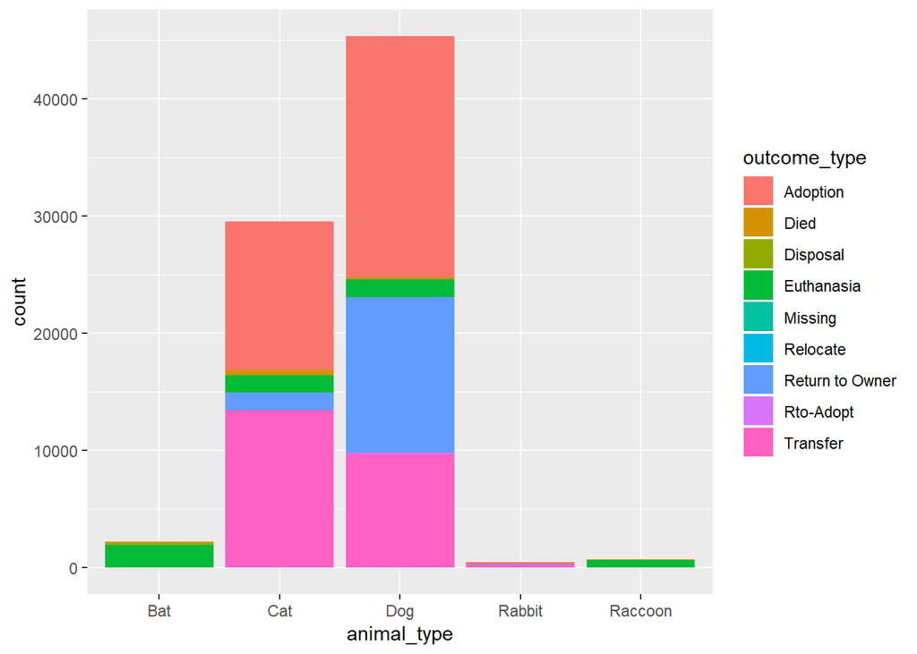

**Code Details**

```r
types <- table(aac_intakes_outcomes2$animal_type, aac_intakes_outcomes2$outcome_type)
types[order(types[,1], decreasing=T),]
```

```
##
##           Adoption  Died Disposal Euthanasia Missing Relocate
##   Dog        20580   142       10       1502      16        0
##   Cat        12673   402       13       1474      29        0
##   Rabbit       172    29        0         26       0        0
##   Bat            0    78      199       1928       0        0
##   Raccoon        0    15       27        658       0        5
##
##           Return to Owner Rto-Adopt Transfer
##   Dog               13272       143     9697
##   Cat                1471        36    13434
##   Rabbit               12         0      274
##   Bat                   0         0        0
##   Raccoon               0         0        1
```

## Einschränkung des OutcomeTypes

Da das Interesse des Tierheims vorallem darin liegt, dass Hunde, Katzen und Hasen *adoptiert* werden, und dieser Anteil auch bei den beiden Tierarten relativ hoch ist, d.h. ausreichend Daten zum Trainieren des Modells vorhanden sind, soll für diese Tierarten dieser *Outcometype* vorhergesagt werden.

### Weitere Einschränkung nach Outcome Type und Tierart

Da der Anteil bei Wildtieren, die eingeschläfert werden, sehr hoch ist, liegen nur wenige Fälle für andere Outcome Types vor, weshalb an dieser Stelle davon abgesehen wird, Modelle für Racoons und Bats aufzustellen.

Im Folgenden wird deshalb der Datensatz weiter reduziert (durch Entfernung der Wildtiere), es sollen ausschließlich Hunde, Katzen und Hasen verbleiben. Es wird eine neue Variable erstellt, die binär codiert angibt, ob das jeweilige Tier adoptiert wurde.

**Code Details**

```r
#entferne wildtiere

aac_intakes_outcomes_3 <- subset(aac_intakes_outcomes2, animal_type  == "Dog" | animal_type == "Cat" | aac_intakes_outcomes2$animal_type  == "Rabbit")
aac_intakes_outcomes_3$animal_type <- factor(aac_intakes_outcomes_3$animal_type)

#dummycodierung für Adoption

dummies_outcometype <- data.frame(aac_intakes_outcomes_3$outcome_type)
dummies_outcometype <- dummy.data.frame(dummies_outcometype)

aac_intakes_outcomes_3$outcome_type_adopt <- dummies_outcometype[,1]
```

**Code Details**

```r
aac_intakes_outcomes_3$outcome_type <- factor(aac_intakes_outcomes_3$outcome_type)
table(aac_intakes_outcomes_3$outcome_type, aac_intakes_outcomes_3$outcome_type_adopt)
```

```
##
##                       0     1
##   Adoption            0 33425
##   Died              573     0
##   Disposal           23     0
##   Euthanasia       3002     0
##   Missing            45     0
##   Return to Owner 14755     0
##   Rto-Adopt         179     0
##   Transfer        23405     0
```

```r
aac_intakes_outcomes2 <- aac_intakes_outcomes_3
```

### Adoptionen nach Tieren

Es liegen ausreichend Daten für die Vorhersage der Adoption vor.

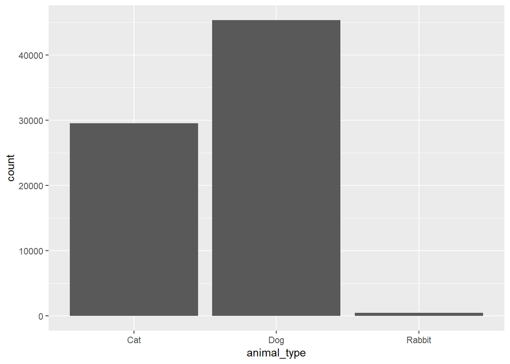

```r
b<- ggplot(aac_intakes_outcomes2, aes(animal_type))+geom_bar(fill = "#0073C2FF")

b+geom_bar(aes(fill = outcome_type_adopt))
```

**Code Details**

```r
t<-table(aac_intakes_outcomes2$outcome_type_adopt, aac_intakes_outcomes2$animal_type)
t
```

```
##
##       Cat   Dog Rabbit
##   0 16859 24782    341
##   1 12673 20580    172
```

```r
#Relative Anteile der Outcometypes
table<- prop.table(t,2)
```

**Code Details**

```r
table(aac_intakes_outcomes2$animal_type, aac_intakes_outcomes2$outcome_type_adopt)
```

```
##
##              0     1
##   Cat    16859 12673
##   Dog    24782 20580
##   Rabbit   341   172
```

Da ein erster Testlauf/Fitting des Datensatzes mit einem Decision Tree aufgrund der Datenstrukturen wenig performant ist, wurden die Daten überwiegend Dummycodiert um ein schnelleres Training zu erzielen.

**Code Details**

```r
#Löschung unbenötigter Spalten: outcometype (alle types) &date_of_birth_month & year

aac_intakes_outcomes2 <- aac_intakes_outcomes2[,c(2:6,9:20)]

#Dummycodierungen

dummies_intake_condition <- dummy.data.frame(data.frame(aac_intakes_outcomes2$intake_condition))
aac_intakes_outcomes2$intake_conditionAged <- dummies_intake_condition[,1]
aac_intakes_outcomes2$intake_conditionFeral <- dummies_intake_condition[,2]
aac_intakes_outcomes2$intake_conditionInjured <- dummies_intake_condition[,3]
aac_intakes_outcomes2$intake_conditionNormal <- dummies_intake_condition[,4]
aac_intakes_outcomes2$intake_conditionNursing <- dummies_intake_condition[,5]
aac_intakes_outcomes2$intake_conditionOther <- dummies_intake_condition[,6]
aac_intakes_outcomes2$intake_conditionPregnant <- dummies_intake_condition[,7]
aac_intakes_outcomes2$intake_conditionSick <- dummies_intake_condition[,8]

dummies_intake_type <- dummy.data.frame(data.frame(aac_intakes_outcomes2$intake_type))
aac_intakes_outcomes2$intake_typeEuthanasiaRequest <- dummies_intake_type[,1]
aac_intakes_outcomes2$intake_typeOwnerSurrender <- dummies_intake_type[,2]
aac_intakes_outcomes2$intake_typePublicAssist <- dummies_intake_type[,3]
aac_intakes_outcomes2$intake_typeStray <- dummies_intake_type[,4]
aac_intakes_outcomes2$intake_typeWildlife <- dummies_intake_type[,5]

dummies_suos <- dummy.data.frame(data.frame(aac_intakes_outcomes2$sex_upon_outcome_second))
aac_intakes_outcomes2$sexuponoutcomesecond_female <- dummies_suos[,1]
aac_intakes_outcomes2$sexuponoutcomesecond_male <- dummies_suos[,2]
aac_intakes_outcomes2$sexuponoutcomesecond_unknown <- dummies_suos[,3]

dummies_intake_month <- dummy.data.frame(data.frame(aac_intakes_outcomes2$intake_month))
aac_intakes_outcomes2$intake_month1 <- dummies_intake_month[,1]
aac_intakes_outcomes2$intake_month2 <- dummies_intake_month[,2]
aac_intakes_outcomes2$intake_month3 <- dummies_intake_month[,3]
aac_intakes_outcomes2$intake_month4 <- dummies_intake_month[,4]
aac_intakes_outcomes2$intake_month5 <- dummies_intake_month[,5]
aac_intakes_outcomes2$intake_month6 <- dummies_intake_month[,6]
aac_intakes_outcomes2$intake_month7 <- dummies_intake_month[,7]
aac_intakes_outcomes2$intake_month8 <- dummies_intake_month[,8]
aac_intakes_outcomes2$intake_month9 <- dummies_intake_month[,9]
aac_intakes_outcomes2$intake_month10 <- dummies_intake_month[,10]
aac_intakes_outcomes2$intake_month11 <- dummies_intake_month[,11]
aac_intakes_outcomes2$intake_month12 <- dummies_intake_month[,12]

dummies_intake_year <- dummy.data.frame(data.frame(aac_intakes_outcomes2$intake_year))
aac_intakes_outcomes2$intake_year2013 <- dummies_intake_year[,1]
aac_intakes_outcomes2$intake_year2014 <- dummies_intake_year[,2]
aac_intakes_outcomes2$intake_year2015 <- dummies_intake_year[,3]
aac_intakes_outcomes2$intake_year2016 <- dummies_intake_year[,4]
aac_intakes_outcomes2$intake_year2017 <- dummies_intake_year[,5]
aac_intakes_outcomes2$intake_year2018 <- dummies_intake_year[,6]

dummies_outcome_month <- dummy.data.frame(data.frame(aac_intakes_outcomes2$outcome_month))
aac_intakes_outcomes2$outcome_month1 <- dummies_outcome_month[,1]
aac_intakes_outcomes2$outcome_month2 <- dummies_outcome_month[,2]
aac_intakes_outcomes2$outcome_month3 <- dummies_outcome_month[,3]
aac_intakes_outcomes2$outcome_month4 <- dummies_outcome_month[,4]
aac_intakes_outcomes2$outcome_month5 <- dummies_outcome_month[,5]
aac_intakes_outcomes2$outcome_month6 <- dummies_outcome_month[,6]
aac_intakes_outcomes2$outcome_month7 <- dummies_outcome_month[,7]
aac_intakes_outcomes2$outcome_month8 <- dummies_outcome_month[,8]
aac_intakes_outcomes2$outcome_month9 <- dummies_outcome_month[,9]
aac_intakes_outcomes2$outcome_month10 <- dummies_outcome_month[,10]
aac_intakes_outcomes2$outcome_month11 <- dummies_outcome_month[,11]
aac_intakes_outcomes2$outcome_month12 <- dummies_outcome_month[,12]

dummies_outcome_year <- dummy.data.frame(data.frame(aac_intakes_outcomes2$outcome_year))
aac_intakes_outcomes2$outcome_year2013 <- dummies_outcome_year[,1]
aac_intakes_outcomes2$outcome_year2014 <- dummies_outcome_year[,2]
aac_intakes_outcomes2$outcome_year2015 <- dummies_outcome_year[,3]
aac_intakes_outcomes2$outcome_year2016 <- dummies_outcome_year[,4]
aac_intakes_outcomes2$outcome_year2017 <- dummies_outcome_year[,5]
aac_intakes_outcomes2$outcome_year2018 <- dummies_outcome_year[,6]

dummies_color <- dummy.data.frame(data.frame(aac_intakes_outcomes2$color_new))

#prüfe ob plausible Farben für übrige Tierrassen.  table(aac_intakes_outcomes2$color_new, aac_intakes_outcomes2$animal_type)
#Grün keine Werte mehr. Andere Farben alle plausibel

aac_intakes_outcomes2$colorApricot <- dummies_color[,1]
aac_intakes_outcomes2$colorBeige <- dummies_color[,2]
aac_intakes_outcomes2$colorBlack <- dummies_color[,3]
aac_intakes_outcomes2$colorBlue <- dummies_color[,4]
aac_intakes_outcomes2$colorBrown <- dummies_color[,5]
aac_intakes_outcomes2$colorGray <- dummies_color[,6]
aac_intakes_outcomes2$colorLilac <- dummies_color[,7]
aac_intakes_outcomes2$colorMulticolor <- dummies_color[,8]
aac_intakes_outcomes2$colorOrange <- dummies_color[,9]
aac_intakes_outcomes2$colorPink <- dummies_color[,10]
aac_intakes_outcomes2$colorRed <- dummies_color[,11]
aac_intakes_outcomes2$colorSilver <- dummies_color[,12]
aac_intakes_outcomes2$colorWhite <- dummies_color[,13]
aac_intakes_outcomes2$colorYellow <- dummies_color[,14]

aac_intakes_outcomes2$age_upon_intake_.days. <- as.numeric(aac_intakes_outcomes2$age_upon_intake_.days.)
aac_intakes_outcomes2$age_upon_outcome_.days. <- as.numeric(aac_intakes_outcomes2$age_upon_outcome_.days.)
aac_intakes_outcomes2$time_in_shelter_days <- as.numeric(aac_intakes_outcomes2$time_in_shelter_days)

dummies_suif<- dummy.data.frame(data.frame(aac_intakes_outcomes2$sex_upon_intake_first))
aac_intakes_outcomes2$sex_upon_intake_first_Intact <- dummies_suif[,1]
aac_intakes_outcomes2$sex_upon_intake_first_Sterilized <- dummies_suif[,2]
aac_intakes_outcomes2$sex_upon_intake_first_Unknown <- dummies_suif[,3]

dummies_suof<- dummy.data.frame(data.frame(aac_intakes_outcomes2$sex_upon_outcome_first))
aac_intakes_outcomes2$sex_upon_outcome_first_Intact <- dummies_suof[,1]
aac_intakes_outcomes2$sex_upon_outcome_first_Sterilized <- dummies_suof[,2]
aac_intakes_outcomes2$sex_upon_outcome_first_Unknown <- dummies_suof[,3]

aac_intakes_outcomes2$outcome_type_adopt <- as.factor(aac_intakes_outcomes2$outcome_type_adopt)
aac_intakes_outcomes2$breed <- as.factor(aac_intakes_outcomes2$breed)

#Entfernen aller 10 Originalspalten, die Dummycodiert wurden

aac_intakes_outcomes2[ ,c('intake_condition', 'intake_type', 'sex_upon_outcome_second', 'intake_month', 'intake_year', 'outcome_month', 'outcome_year', 'color_new', 'sex_upon_intake_first', 'sex_upon_outcome_first')] <- list(NULL)
```

# Finale Datensätze zur Modellierung

Als Basis für einen Gesamtdatensatz zur Modellierung werden die drei ausgewählten Tierarten dummycodiert.

```r
allanimals <- aac_intakes_outcomes2
dummies_animals<- dummy.data.frame(data.frame(allanimals$animal_type))

allanimals$cat <- dummies_animals[,1]
allanimals$dog <- dummies_animals[,2]
allanimals$rabbit <- dummies_animals[,3]

allanimals<- allanimals[,-c(1)]
```

## Split Daten nach Tier

Es werden außerdem Datasets pro Tierart erstellt. Da für jede Tierart ein eigenes Modell gefittet wird, wird die Tierartvariable innerhalb dieser Datensätze nicht benötigt und entfernt.

```r
rabbits <- subset(aac_intakes_outcomes2, animal_type == "Rabbit")
rabbits <- rabbits[,-c(1)]
rabbits$ breed <- as.factor(rabbits$breed)

dogs <- subset(aac_intakes_outcomes2, animal_type == "Dog")
dogs <- dogs[,-c(1)]
dogs$breed <- as.factor(dogs$breed)

cats <- subset(aac_intakes_outcomes2, animal_type == "Cat")
cats <- cats[,-c(1)]
cats$breed <- as.factor(cats$breed)
```

### Train Test Split - alle Tierarten

**Code Details**

```r
train_function <- createDataPartition(
  y = allanimals$outcome_type_adopt,
  p = .70,
  list = FALSE
)

training <- allanimals[ train_function,]
testing  <- allanimals[-train_function,]
```

### Train/Test Split für Hunde

Jedes Subset wird wiederum in ein Test- und Trainingsset unterteilt. Beispiel Hunde:

```r
train_function <- createDataPartition(
  y = dogs$outcome_type_adopt,
  p = .70,
  list = FALSE
)

training_dog <- dogs[train_function,]
testing_dog  <- dogs[-train_function,]
```

### Train/Test Split für Katzen

**Code Details**

```r
train_function <- createDataPartition(
  y = cats$outcome_type_adopt,
  p = .70,
  list = FALSE
)

training_cat <- cats[ train_function,]
testing_cat  <- cats[-train_function,]
```

### Train/Test Split für Hasen

**Code Details**

```r
train_function <- createDataPartition(
  y = rabbits$outcome_type_adopt,
  p = .70,
  list = FALSE
)

training_rabbit <- rabbits[ train_function,]
testing_rabbit  <- rabbits[-train_function,]
```

# Aufstellen der Modelle

Zuerst werden Modelle mithilfe von Decision Trees aufgestellt, da diese gut interpretierbar sind. Danach wird untersucht, ob andere Methoden wie neuronale Netze ein ähnliches oder sogar besseres Ergebnis hinsichtlich Accuracy liefern.

## Decision Trees

Allgemeine Werte

```r
cv_5 = trainControl(method = "cv", number = 5)
seed_val = 123
```

Laden der gespeicherten Decision Tree Modelle

```r
if (file.exists("decision_trees.RData") && !exists("tree_dog1") && !exists("tree_cat1") && !exists("tree_rabbit1"))
  load("decision_trees.RData")
```

### Decision Tree für Hunde

Wie auch bei der Datensatzerstellung je Tierart werden im Folgenden pro Tierart Klassifikationsbäume mit 5-fold Cross-Validation gefittet. Dafür werden alle Variablen im Datensatz und die Methode ‘rpart’ aus dem Caret Package verwendet, um eine Adoption vorherzusagen.

```r
set.seed(seed_val)

if (!exists("tree_dog1"))
  tree_dog1 <- train(
    outcome_type_adopt ~ .,
    data = training_dog,
    trControl = cv_5,
    method = "rpart")
```

Das gefittete Modell:

```
## CART
##
## 31754 samples
##    77 predictor
##     2 classes: '0', '1'
##
## No pre-processing
## Resampling: Cross-Validated (5 fold)
## Summary of sample sizes: 25404, 25403, 25403, 25403, 25403
## Resampling results across tuning parameters:
##
##   cp          Accuracy   Kappa
##   0.07684298  0.7833977  0.5702903
##   0.14327364  0.7234353  0.4598999
##   0.33645703  0.6353547  0.2441332
##
## Accuracy was used to select the optimal model using the largest value.
## The final value used for the model was cp = 0.07684298.
```

```
## Confusion Matrix and Statistics
##
##           Reference
## Prediction    0    1
##          0 5050  801
##          1 2384 5373
##
##                Accuracy : 0.7659
##                  95% CI : (0.7587, 0.773)
##     No Information Rate : 0.5463
##     P-Value [Acc > NIR] : < 2.2e-16
##
##                   Kappa : 0.5379
##  Mcnemar's Test P-Value : < 2.2e-16
##
##             Sensitivity : 0.6793
##             Specificity : 0.8703
##          Pos Pred Value : 0.8631
##          Neg Pred Value : 0.6927
##              Prevalence : 0.5463
##          Detection Rate : 0.3711
##    Detection Prevalence : 0.4300
##       Balanced Accuracy : 0.7748
##
##        'Positive' Class : 0
##
```

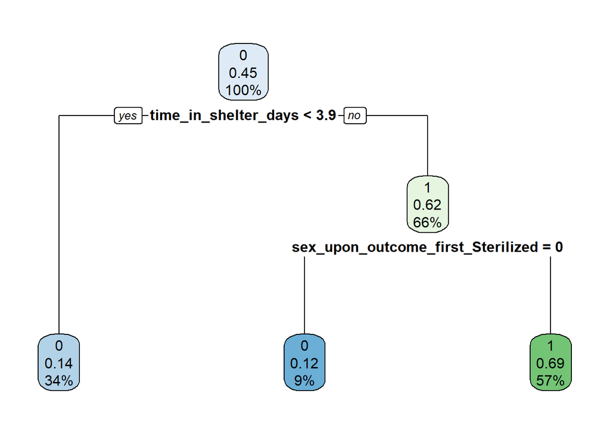

*Interpretation*

Der Tree zeigt, dass zuerst `time_in_shelter_days` eine Rolle spielt und somit die erste Abzweigung im Baum ist. Als weitere Variable verwendet der Baum `sex_upon_outcome_first_Sterilized` = 0. Wenn der Hund weniger als 4 Tage im Tierheim ist, scheint eine Adoption auf Basis des Modells also als unwahrscheinlich (vermutlich handelt es sich dabei um entlaufene Tiere die bereits innerhalb der ersten 4 Tage wieder vom Besitzer abgeholt werden), wohingegen bei Hunden, die länger als 4 Tage im Tierheim verbleiben, die Wahrscheinlichkeit einer Adoption dann hoch ist, wenn der Hund sterilisiert ist.

### Decision Tree für Katzen

**Code Details**

```r
set.seed(seed_val)
if (!exists("tree_cat1"))
  tree_cat1 <- train(
    outcome_type_adopt ~ .,
    data = training_cat,
    trControl = cv_5,
    method = "rpart")
```

Das gefittete Modell:

```
## CART
##
## 20674 samples
##    77 predictor
##     2 classes: '0', '1'
##
## No pre-processing
## Resampling: Cross-Validated (5 fold)
## Summary of sample sizes: 16540, 16539, 16538, 16539, 16540
## Resampling results across tuning parameters:
##
##   cp          Accuracy   Kappa
##   0.05489179  0.8320137  0.6545231
##   0.06841749  0.8097634  0.6137778
##   0.50721371  0.6561340  0.2317856
##
## Accuracy was used to select the optimal model using the largest value.
## The final value used for the model was cp = 0.05489179.
```

```
## Confusion Matrix and Statistics
##
##           Reference
## Prediction    0    1
##          0 4804 1369
##          1  253 2432
##
##                Accuracy : 0.8169
##                  95% CI : (0.8087, 0.8249)
##     No Information Rate : 0.5709
##     P-Value [Acc > NIR] : < 2.2e-16
##
##                   Kappa : 0.6121
##  Mcnemar's Test P-Value : < 2.2e-16
##
##             Sensitivity : 0.9500
##             Specificity : 0.6398
##          Pos Pred Value : 0.7782
##          Neg Pred Value : 0.9058
##              Prevalence : 0.5709
##          Detection Rate : 0.5423
##    Detection Prevalence : 0.6969
##       Balanced Accuracy : 0.7949
##
##        'Positive' Class : 0
##
```

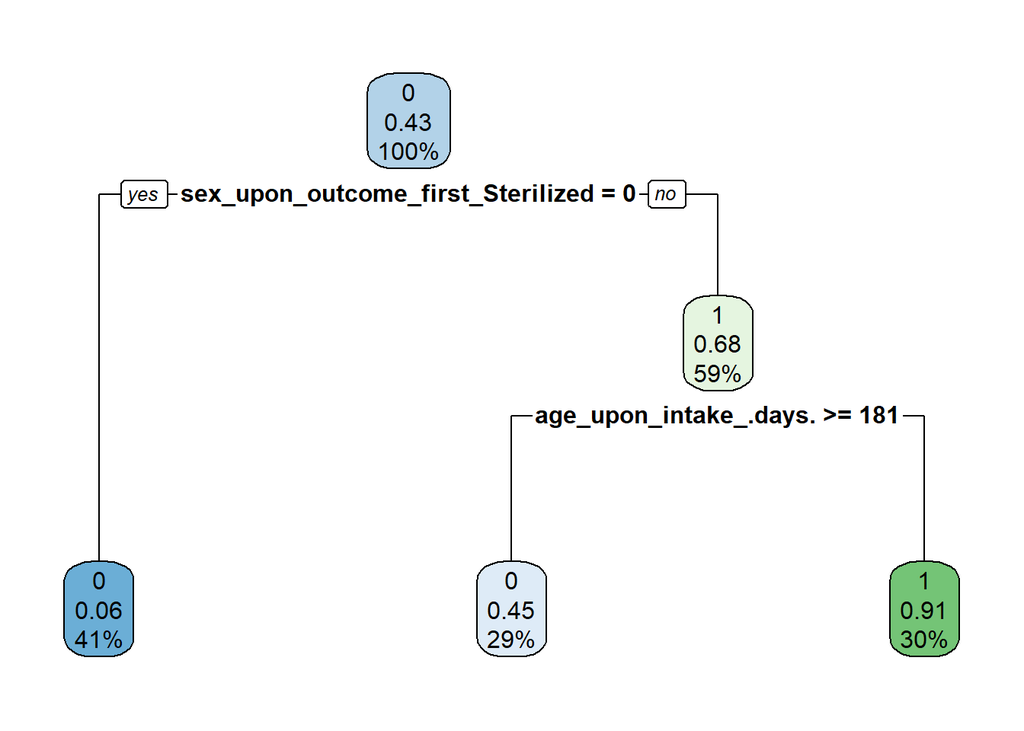

*Interpretation*

Bei Katzen ist `sex_upon_outcome_first_Sterilized` = 0 die erste Split Variable des Baumes, gefolgt von dem Alter der Katze bei Intake. Daher scheinen für die Adoption einer Katze ähnliche Kriterien eine Rolle zu spielen, wie bei Hunden. Im Gegensatz zur Wahrscheinlichkeit einer Adoption eines Hundes spielt diesem Klassifikationsbaum zufolge das Alter der Katze eine wichtige Rolle: Wenn die Katze sterilisiert, und jünger als ein halbes Jahr ist, ist eine Adoption wahrscheinlicher. Ist die Katze älter als ein halbes Jahr, wird sie eher nicht adoptiert. Dies könnte daran liegen, dass Jungtiere bevorzugt adoptiert werden.

### Decision Tree für Hasen

**Code Details**

```r
set.seed(seed_val)

if (!exists("tree_rabbit1"))
  tree_rabbit1 <- train(
    outcome_type_adopt ~ .,
    data = training_rabbit,
    trControl = cv_5,
    method = "rpart")
```

Das gefittete Modell:

```
## CART
##
## 360 samples
##  77 predictor
##   2 classes: '0', '1'
##
## No pre-processing
## Resampling: Cross-Validated (5 fold)
## Summary of sample sizes: 288, 288, 288, 288, 288
## Resampling results across tuning parameters:
##
##   cp           Accuracy   Kappa
##   0.008264463  0.8944444  0.7639429
##   0.027548209  0.8916667  0.7579341
##   0.710743802  0.7500000  0.2926217
##
## Accuracy was used to select the optimal model using the largest value.
## The final value used for the model was cp = 0.008264463.
```

```
## Confusion Matrix and Statistics
##
##           Reference
## Prediction  0  1
##          0 97  5
##          1  5 46
##
##                Accuracy : 0.9346
##                  95% CI : (0.8831, 0.9682)
##     No Information Rate : 0.6667
##     P-Value [Acc > NIR] : 1.854e-15
##
##                   Kappa : 0.8529
##  Mcnemar's Test P-Value : 1
##
##             Sensitivity : 0.9510
##             Specificity : 0.9020
##          Pos Pred Value : 0.9510
##          Neg Pred Value : 0.9020
##              Prevalence : 0.6667
##          Detection Rate : 0.6340
##    Detection Prevalence : 0.6667
##       Balanced Accuracy : 0.9265
##
##        'Positive' Class : 0
##
```

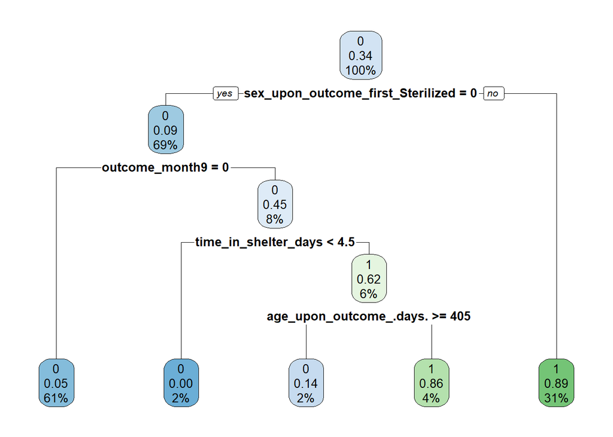

*Interpretation*

Bei Hasen gibt es 4 Splits: `sex_upon_outcome_first_Sterilized` = 0, `outcome_month9` = 0, `time_in_shelter_days` < 4.5, `age_upon_outcome_.days.` >= 405. Daher erfolgt die erste Vorhersage einer Adoption eines Hasens auf Basis der Information, ob das Tier sterilisiert ist. Wie auch bei den anderen Tieren ist die Adoptionswahrscheinlichkeit dann deutlich höher, wenn das Tier bereits sterilisiert ist. Bei nicht sterilisierten Hasen, werden im Monat September jene, die länger als 4 Tage im Tierheim waren und jünger als 13 Monate sind eher adoptiert. Die Accuracy ist mit 93% noch besser als jene der anderen beiden Trees (Hunde und Katzen).

**Code Details**

```r
if (!file.exists("decision_trees.RData"))
  save(tree_dog1, tree_cat1, tree_rabbit1, file = "decision_trees.RData")
```

## Variable Importance

Je Modell ist eine Tabelle der Wichtigkeit einer Variable sowie eine Grafik dargestellt. Die Tabelle enthält lediglich Variablen, bei denen die Importance größer 0 ist.

Die einfachen Klassifikationsbäume geben bereits einen guten ersten Einblick darin, welche Variablen für die Klassifikation bzw. Splitpunkte vorrangig herangezogen werden. Da sich zeigt, dass über die Tierarten hinweg die Hauptsplitpunkte auf ähnlichen Variablen basieren, soll mithilfe der Variable Importance ermittelt werden, ob noch weitere Zusatzinformationen aus den Modellen gewonnen werden können, die für das Tierheim für das bessere Verständnis von Adoptionsgründen genutzt werden kann. Dafür wird die Variable Importance aus den obig erstellten Bäumen (je Tier) erstellt und beschrieben.

### Variable Importance des Hundemodells

```r
imp_dog = vi(tree_dog1)
imp_dog = imp_dog[imp_dog$Importance>0,]
imp_dog_tab = tibble(Variable = imp_dog$Variable, Importance = imp_dog$Importance)
imp_dog_tab
```

```
## # A tibble: 6 x 2
##   Variable                          Importance
##   <chr>                                  <dbl>
## 1 sex_upon_outcome_first_Sterilized      100
## 2 sex_upon_outcome_first_Intact           96.6
## 3 time_in_shelter_days                    80.1
## 4 intake_typePublicAssist                 49.2
## 5 age_upon_intake_.days.                  29.9
## 6 intake_typeStray                        12.2
```

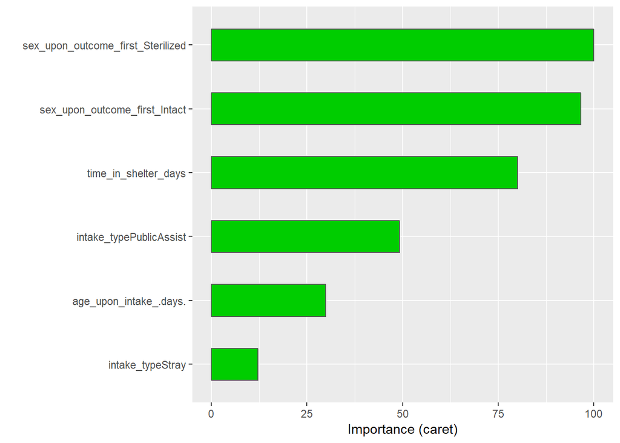

```r
vip(tree_dog1, width = 0.5, fill = "green3", num_features = 6)
```

Es ist ersichtlich, dass für den Decision Tree der Hunde 6 Prädiktoren eine Rolle spielen:

- `sex_upon_outcome_first_Sterilized`
- `sex_upon_outcome_first_Intact`
- `time_in_shelter_days`
- `intake_typePublic Assist`
- `age_upon_intake_.days.`
- `intake_typeStray`

Die wichtigsten Variablen sind neben der bereits im Decisiontree als Splitpunkt ermittelten `sex_upon_outcome_first_Sterilized` auch das `sex_upon_outcome_first_Intact.`

### Variable Importance des Katzenmodells

```
## # A tibble: 8 x 2
##   Variable                          Importance
##   <chr>                                  <dbl>
## 1 time_in_shelter_days                   100
## 2 sex_upon_outcome_first_Sterilized       95.7
## 3 age_upon_outcome_.days.                 75.0
## 4 sex_upon_outcome_first_Intact           59.9
## 5 age_upon_intake_.days.                  31.6
## 6 sex_upon_intake_first_Intact            21.9
## 7 sex_upon_intake_first_Sterilized        21.9
## 8 sexuponoutcomesecond_unknown            17.9
```

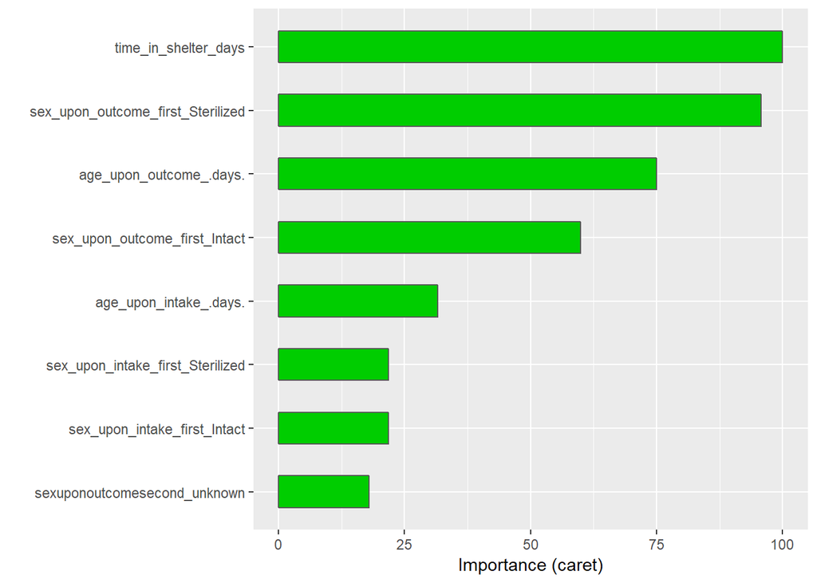

Im Modell der Katzen finden sich ähnliche Prädiktoren wieder, hinzugekommen sind hier:

- `age_upon_outcome_.days.`
- `sex_upon_intake_first_Sterilized`
- `sex_upon_intake_first_Intact`
- `sexuponoutcomesecond_unknown`

Hier ist im Gegensatz zu den Hunden das Alter der Tiere und die `time_in_shelter` am wichtigsten.

### Variable Importance des Hasenmodells

```
## # A tibble: 13 x 2
##    Variable                          Importance
##    <chr>                                  <dbl>
##  1 sex_upon_outcome_first_Sterilized     100
##  2 time_in_shelter_days                   66.2
##  3 sex_upon_intake_first_Unknown          40.8
##  4 sex_upon_outcome_first_Unknown         40.8
##  5 sexuponoutcomesecond_unknown           40.8
##  6 outcome_month9                          8.54
##  7 intake_year2016                         7.68
##  8 age_upon_intake_.days.                  6.19
##  9 age_upon_outcome_.days.                 4.88
## 10 outcome_year2016                        4.64
## 11 intake_month9                           3.87
## 12 sex_upon_intake_first_Intact            3.02
## 13 sex_upon_outcome_first_Intact           3.02
```

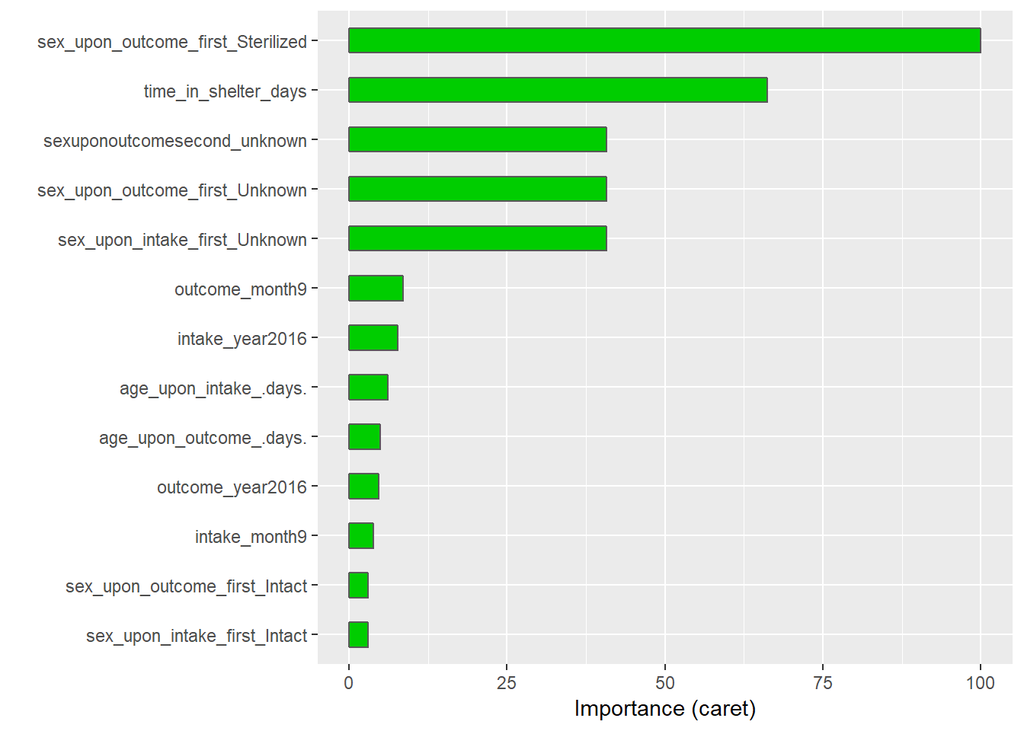

von Bedeutung.

Die Relevanz der Jahreszeiten lässt darauf schließen, dass die Adoptionen von Hasen sich über die Jahre hinweg unterscheiden. Was Grund für das Ausreißerjahr 2016 war, müsste anhand von Brancheninformationen ermittelt werden, es könnt z.B. sein, dass es vermehrte mediale Aufmerksamkeit (z.B. durch Kampagnen / Testimonials) oder eine Art “Haustiertrend-Boost” für Hasen in diesem Jahr gab. Sollten sich die besonderen Outcome Jahre und Monate auf ein außergewöhnliches Ereignis zurückführen lassen, muss nochmals bewertet werden, ob diese Daten im Modell berücksichtigt werden sollten.

## Tree Tuning (Bagging, Boosting, Random Forest)

Es wurde versucht, noch weitere Trees, getunt mit Bagging, Boosting bzw. Random Forest, aufzustellen. Aufgrund der Datenmenge und Rechenkapaziätsgrenzen konnten diese nicht ausgeführt werden und es ist hier nur ein Beispielcode bzw. ein gespeichertes Beispielmodel angeführt. In einem weiteren Schritt werden daher weitere Modelle mit Neuronalen Netzen berechnet.

### Auswahl Daten

Bei der Auswahl der Daten wurde auch versucht, die nummerischen Variablen bzw. die Breed auszuschließen, dies hat allerdings auch zu keinem erfolgreich gefitteten Modell geführt.

```r
data_train_model <- training_cat[,-c(1:5)]
data_test_model <- testing_cat[,-c(1:5)]
```

### Random Forrest mit OOB

```r
trcOOB <- trainControl(method="oob")

randomforest_OOB <- train(
  outcome_type_adopt ~ .,
  data = data_train_model,
  method = "rf",
  tuneGrid = expand.grid(mtry=seq(1,10,1)),
  trControl = trcOOB
)
```

```r
RF_OOB_predict = predict(randomforest_OOB, data_test_model)
conf_matrix_RF_OOB <- confusionMatrix(RF_OOB_predict, data_test_model$outcome_type)
```

### Modell für Katzen

Der Random Forest mit OOB konnte beispielhaft für ein reduziertes Subsample mit 1000 Cat-Datensätzen gespeichert werden, wird aber nicht weiter herangezogen.

```r
load("randomforestOOB_cats_n=1000.Rdata")
```

## Neuronales Netzwerk

Die Bäume dienen als gut interpretierbare Modelle für ein besseres Verständnis der Adoptionsgründe. Nun soll noch getestet werden, ob ein Modell, dass stärker auf Vorhersage als auf Interpretierbarkeit abzielt, helfen kann, die Modellaccuracy noch weiter zu steigern. Bei den neuronalen Netzen wird die Variable `breed` ausgeschlossen, da sie bei den Bäumen als nicht relevant identifiziert wurde. Außerdem werden die numerischen Variablen `intake_number`, `age_upon_intake_.days.`, `age_upon_outcome_.days.` und `time_in_shelter_days` vorab min-max normalisiert, um die Geschwindigkeit der Berechnung zu erhöhen (für das Hundedatenset konnte ohne Normalisierung aus Computer Performance technischen Gründen gar keine Berechnung durchgeführt werden). Die Normalisierung ermöglichte dann eine (schnellere) Berechnung. Es werden für jede Tierart jeweils zwei neuronale Netze erstellt, einmal mit allen Variablen und einmal mit den Variablen, die im Decision Tree schon als wichtig festgestellt wurden.

Es wird erwartet, dass das Modell, das alle Variablen inkludiert, eine höhere Accuracy erzielt als jenes, das nur eine Teilmenge der Variablen enthält (weil die Mustererkennung unter Berücksichtigung von mehr Variablen genauer sein müsste). Andererseits soll auch getestet werden, ob ausschließlich unter Verwendung der (auf Basis der Variable Importance) wichtigsten Prädiktoren ein gleich gutes Ergebnis erzielt werden kann, wie mit dem gefitteten einfachen Baummodell.

**Code Details**

```r
if (file.exists("neuronale_netze.RData"))
  load("neuronale_netze.RData")
```

Definition von allgemeinen Funktionen

```r
maxidx <- function(arr) {
    return(which(arr == max(arr)))
}

normalize <- function(x) {
  return ((x - min(x)) / (max(x) - min(x)))
}
```

### Neuronales Netz für Hunde

Wie auch bei den Decision Trees wird pro Tierrasse ein Modell mit denselben Parametern wie für die anderen Tierrassen gefittet.

Modellfitting unter Verwendung aller Variablen (normalisiert) außer Breed:

```r
set.seed(seed_val)

#Normalisierung der numerischen Variablen (Spalten 2-5)
training_dog_norm = training_dog
training_dog_norm[c(2:5)] <- as.data.frame(lapply(training_dog_norm[c(2:5)], normalize))

testing_dog_norm = testing_dog
testing_dog_norm[c(2:5)] <- as.data.frame(lapply(testing_dog_norm[c(2:5)], normalize))


#'Fullmodel' Fitting

if (!exists("net_model_dog"))
  net_model_dog <- neuralnet(outcome_type_adopt ~ .,
                  data=training_dog_norm[c(2:78)],
                  hidden=c(3),
                  stepmax = 1000000,
                  threshold = 1,
                  linear.output=T,
                  act.fct = "logistic")
```

Modellfitting mit einer Teilmenge/ Auswahl von Variablen (Auswahl auf Basis der Feature Importance):

```r
set.seed(seed_val)

if (!exists("net_model_dog_selected"))
  net_model_dog_selected <- neuralnet(outcome_type_adopt ~ time_in_shelter_days+sex_upon_outcome_first_Sterilized,
                  data=training_dog_norm[c(2:78)],
                  hidden=c(3),
                  stepmax = 1000000,
                  threshold = 1,
                  linear.output=T,
                  act.fct = "logistic")
```

Visualisierung des neuronalen Netzes mit den wichtigen Features aus dem Decision Tree

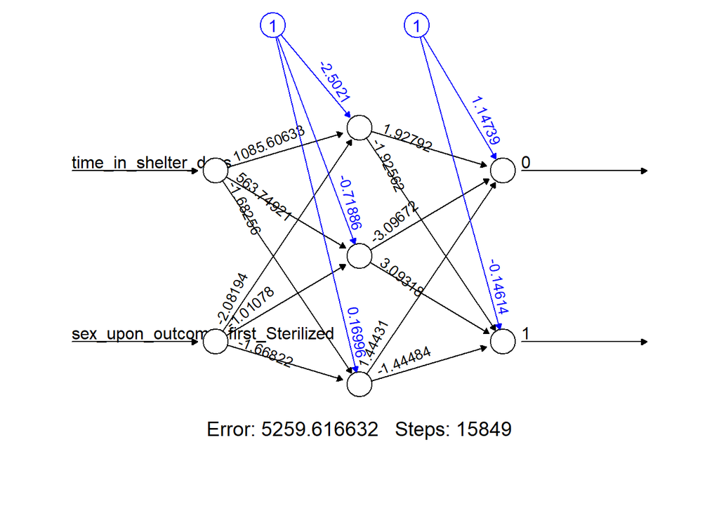

Vergleich der Accuracy der Modelle

```r
#Vorhersage für Modell mit allen Variablen
pred_net_dog <- predict(net_model_dog,testing_dog_norm[c(2:78)])
idx <- apply(pred_net_dog, c(1), maxidx)
pred_net_dog <-as.factor(c('0', '1')[idx])

#Vorhersage für Modell mit Teilmenge von Variablen
pred_net_dog_selected <- predict(net_model_dog_selected,testing_dog_norm[c(2:78)])
idx <- apply(pred_net_dog_selected, c(1), maxidx)
pred_net_dog_selected <-as.factor(c('0', '1')[idx])

#Confusion Matrizen für beide Modelle
cf_net_dog <- confusionMatrix(pred_net_dog,testing_dog_norm$outcome_type_adopt)
cf_net_dog_selected <- confusionMatrix(pred_net_dog_selected,testing_dog_norm$outcome_type_adopt)

cat("All Variables: Accuracy", cf_net_dog$overall["Accuracy"], "\n")
```

```
## All Variables: Accuracy 0.8209142
```

```r
cat("Selected Variables: Accuracy", cf_net_dog_selected$overall["Accuracy"], "\n")
```

```
## Selected Variables: Accuracy 0.7523516
```

*Interpretation*

Die Accuracy des NNs für Hunde ist unter Berücksichtigung aller Variablen deutlich besser als unter Verwendung eines Subsets und übertrifft in der Accuracy auch den Decision Tree.

### Neuronales Netz für Katzen

**Code Details**

```r
set.seed(seed_val)

training_cat_norm = training_cat
training_cat_norm[c(2:5)] <- as.data.frame(lapply(training_cat_norm[c(2:5)], normalize))

testing_cat_norm = testing_cat
testing_cat_norm[c(2:5)] <- as.data.frame(lapply(testing_cat_norm[c(2:5)], normalize))


if (!exists("net_model_cat"))
  net_model_cat <- neuralnet(outcome_type_adopt ~ .,
                  data=training_cat_norm[c(2:78)],
                  hidden=c(3),
                  stepmax = 1000000,
                  threshold = 1,
                  act.fct = "logistic")
```

**Code Details**

```r
set.seed(seed_val)

if (!exists("net_model_cat_selected"))
  net_model_cat_selected <- neuralnet(outcome_type_adopt ~ sex_upon_outcome_first_Sterilized+age_upon_intake_.days.,
                  data=training_cat_norm[c(2:78)],
                  hidden=c(3),
                  stepmax = 1000000,
                  threshold = 1,
                  act.fct = "logistic")
```

Visualisierung des neuronalen Netzes mit den wichtigen Features aus dem Decision Tree

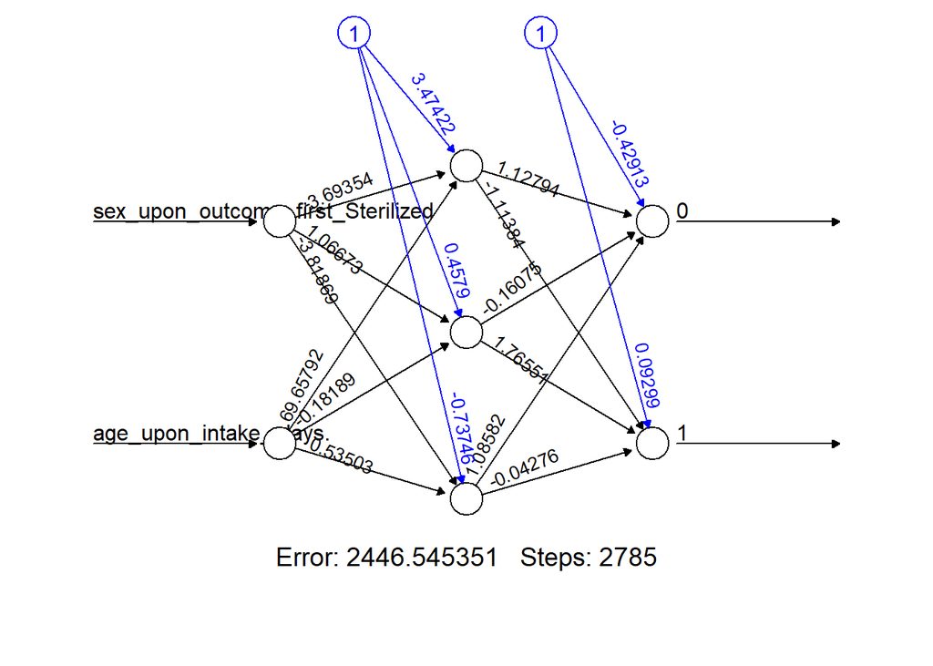

Vergleich der Accuracy der Modelle

```
## All Variables: Accuracy 0.8681418
```

```
## Selected Variables: Accuracy 0.8190336
```

*Interpretation*

Die Accuracy des NNs für Katzen ist unter Berücksichtigung aller Variablen deutlich besser als unter Verwendung eines Subsets. Die Accuracy des Treemodels kann mit dem Neuronalen Netz um etwa 5% verbessert werden.

### Neuronales Netz für Hasen

**Code Details**

```r
set.seed(seed_val)
training_rabbit_norm = training_rabbit
training_rabbit_norm[c(2:5)] <- as.data.frame(lapply(training_rabbit_norm[c(2:5)], normalize))

testing_rabbit_norm = testing_rabbit
testing_rabbit_norm[c(2:5)] <- as.data.frame(lapply(testing_rabbit_norm[c(2:5)], normalize))


if (!exists("net_model_rabbit"))
  net_model_rabbit <- neuralnet(outcome_type_adopt ~ .,
                  data=training_rabbit[c(2:78)],
                  hidden=c(3),
                  stepmax = 1000000,
                  threshold = 1,
                  act.fct = "logistic")
```

**Code Details**

```r
set.seed(seed_val)
if (!exists("net_model_rabbit_selected"))
  net_model_rabbit_selected <- neuralnet(outcome_type_adopt ~ sex_upon_outcome_first_Sterilized+outcome_month9+time_in_shelter_days+age_upon_outcome_.days.,
                  data=training_rabbit[c(2:78)],
                  hidden=c(3),
                  stepmax = 1000000,
                  threshold = 1,
                  act.fct = "logistic")
```

Visualisierung des neuronalen Netzes mit den wichtigen Features aus dem Decision Tree

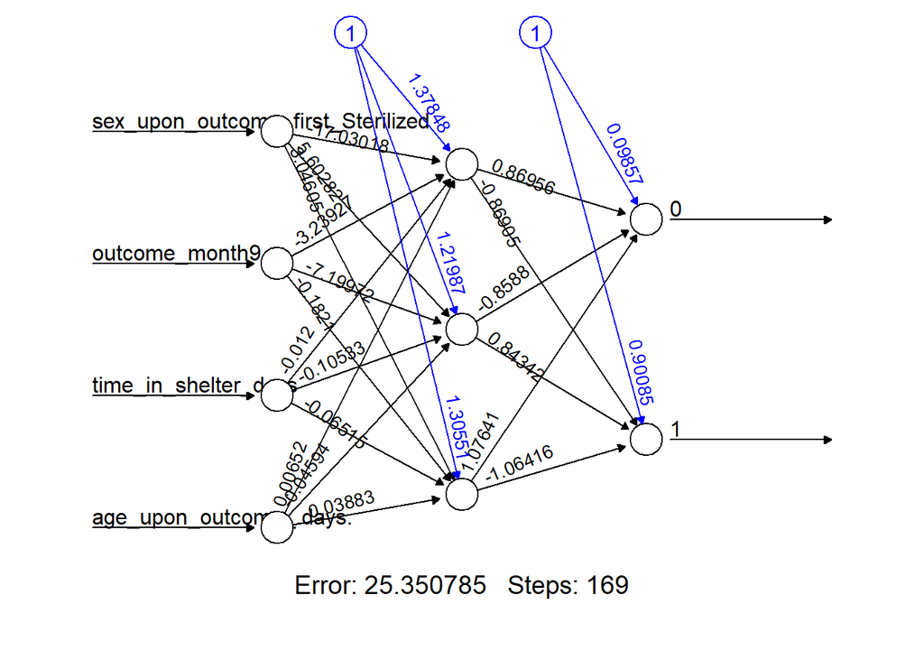

Vergleich der Accuracy der Modelle

```
## All Variables: Accuracy 0.9150327
```

```
## Selected Variables: Accuracy 0.9019608
```

#### Variable Importance im NN

Da die in den Bäumen ermittelten Variablen mit hoher Wichtigkeit für das Hasen Modell stark von jenen für Hunde und Katzen abweichen, wurde noch ein weiteres Neuronales Net (andere Library, die auch Einsicht der Variablen Importance des NNs ermöglicht) gefittet, um zu prüfen, inwiefern die Relevanz der Variablen im Neuronalen Netz von jenen abweicht, die im Tree ermittelt wurden.

**Code Details**

```r
set.seed(123)
control <- trainControl(method = 'cv', number = 10)

nnet_model_rabbit <- train(outcome_type_adopt ~., data = training_rabbit_norm[2:78], method = 'nnet', trControl = control, tuneGrid=expand.grid(size=c(10), decay=c(0.1)), maxi = 100000 )

pred_nnet_rabbit <- predict(nnet_model_rabbit,testing_rabbit_norm[c(2:5,7:78)])
cf_nnet_rabbit <- confusionMatrix(pred_nnet_rabbit,testing_rabbit_norm$outcome_type_adopt)
cat("All Variables: Accuracy", cf_nnet_rabbit$overall["Accuracy"], "\n")
```

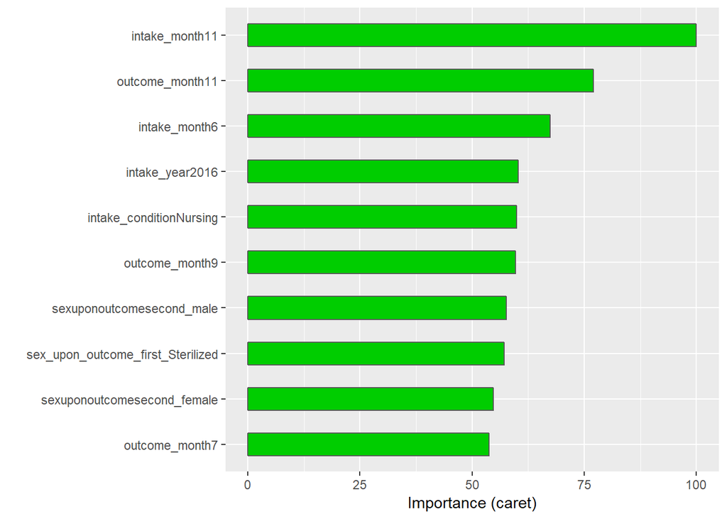

```r
imp_nn_s_rab = vi(nnet_model_rabbit)
imp_nn_s_rab = imp_nn_s_rab[imp_nn_s_rab$Importance>5,]
imp_nn_s_rab_tab = tibble(Variable = imp_nn_s_rab$Variable, Importance = imp_nn_s_rab$Importance)

vip(nnet_model_rabbit, width = 0.5, fill = "green3")
```

Neben der Sterilisation, die im Tree eine der wichtigsten Variable darstellt, spielten beim Neuronalen Netz vorrangig Monate und Jahre, in denen der Hase ins Tierheim gekommen ist bzw. das Tierheim verlassen hat, eine Rolle. Diese weichen leicht von den wichtigen Variablen im Tree ab. Die Darstellung bestätigt aber jedenfalls nochmals, dass bei Hasen tatsächlich Saisoninformationen hilfreich dafür sind, die Adoption vorherzusagen.

### Vergleich aller Neuronalen Netzwerke

| Tierart | Accuracy_All | Accuracy_Selected_Features |
| --- | --- | --- |
| Hunde | 0.8209142 | 0.7523516 |
| Katzen | 0.8681418 | 0.8190336 |
| Hasen | 0.9150327 | 0.9019608 |

Tabelle 1: Accuracies der Neuronalen Netze

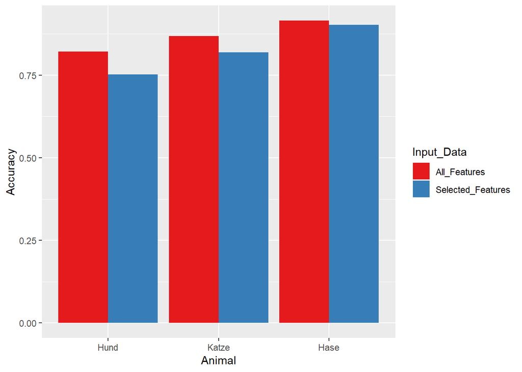

**Code Details**

```r
if (!file.exists("neuronale_netze.RData"))
  save(net_model_dog, net_model_dog_selected, net_model_cat, net_model_cat_selected, net_model_rabbit,net_model_rabbit_selected, file = "neuronale_netze.RData")
```

# Conclusion

Das Vorgehen bei der Prädiktion hat zufriedenstellende Ergebnisse geliefert. Es konnten einerseits relevante Faktoren für die Adoption der am häufigsten im Tierheim vorhandenen Tierarten eruiert werden, andererseits konnten Neuronale Netze mit guter Accuracy (über 80%, siehe Tabelle 2) gefittet werden.

| Modell | Hunde | Katzen | Hasen |
| --- | --- | --- | --- |
| Decision Tree | 0.7659465 | 0.8168887 | 0.9346405 |
| Neuronales Netz | 0.8209142 | 0.8681418 | 0.9150327 |

Tabelle 2: Test-Accuracies der Modelle

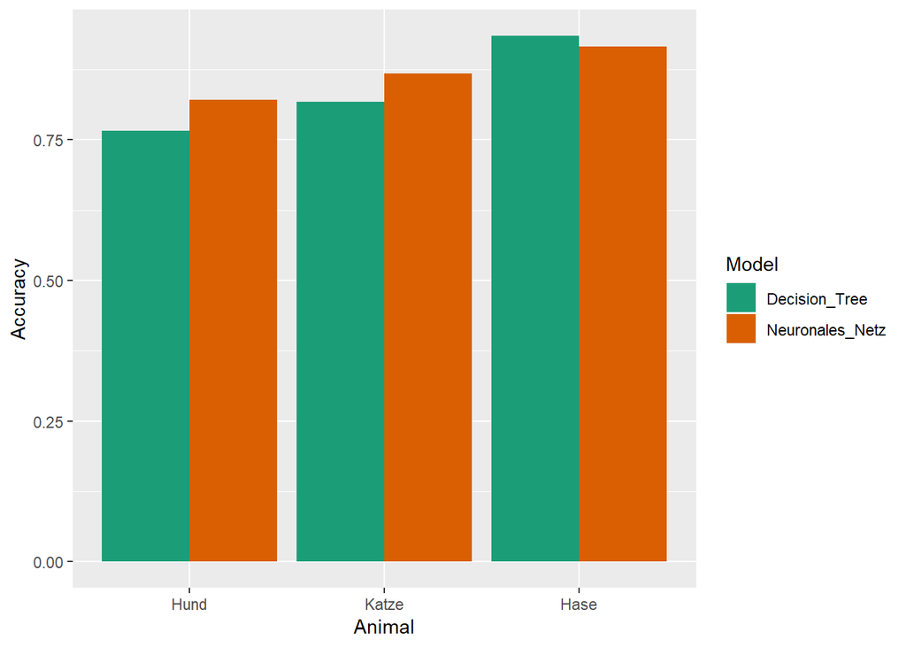

Die anfangs formulierte Hypothese, dass die Adoption vor allem vom Alter und Gesundheitszustand abhängig ist, konnte nur teilweise verifiziert werden. Außerdem stellte sich heraus, dass für unterschiedliche Tierarten unterschiedliche Faktoren und in unterschiedlichem Ausmaß einen Einfluss auf die Adoptionswahrscheinlichkeit nehmen.

Bei Hunden sind die Sterilisation, die Zeitdauer im Tierheim, das Alter und ob es sich um einen Streuner handelt die wichtigsten Kriterien. Für das Tierheim bedeutet das, dass durch eine Sterilization die Adoption wahrscheinlich am stärksten beeinflusst werden kann. Bei Katzen ist das Alter für die Adoption relevanter als bei Hunden, aber auch bei dieser Tierart spielt die Sterilisation eine bedeutende Rolle.

Das Tierheim könnte mit diesen Modellen besser einschätzen, ob und unter welchen Bedingungen gewisse Hunde, Katzen und Hasen eher adoptiert werden. Außerdem können für jene, die eher nicht adoptiert werden, gegebenfalls zusätzliche Maßnahmen (Sterilisation, Marketing, …) getroffen werden, um auch ihre Chance auf eine Adoption zu erhöhen.

[figure not shown]